# Module 10 Brian Tierney BAE 495

Brian Tierney

11/10/2021

# Background

Pollutants such as particulate matter, ozone, nitrogen oxide, hydrocarbons, volatile organic compounds, and other pollutants are monitored across the country by the U.S. Environmental Protection Agency (EPA). We’ll specifically focus on two pollutants in this exercise: PM2.5 and ozone. PM2.5 consists of airborne particulate matter (“PM”) smaller than 2.5 μm in diameter. Ozone (O3) is created through an atmospheric reaction with nitrogen dioxide and sunlight. At high levels, PM2.5 and ozone can cause respiratory issues, thus they are continuously monitored and used to issue public health advisories.

In this report I will analyse data from Linville Falls and Frying Pan Mountain to form a conclusion as to whether or not I think the Linville Falls station for recording air data should be closed or not.

# Analysis

Load Libraries

```r
library(tidyverse)
library(lubridate)
library(corrr)
library(broom)
library(modelr)
library(knitr)
library(janitor)
```

Read the data files into R

```r
o3_2019 <- read_csv("data/o3_2019.csv")
pm25_2019 <- read_csv("data/pm25_2019.csv")
```

### Tidy The Data

```r
pm25_2019 %>%
  clean_names() %>%
  filter(site_name %in% c("Frying Pan Mountain", "Linville Falls")) %>%
  dplyr::select(date, site_name, daily_mean_pm2_5_concentration) %>%
  pivot_wider(names_from = site_name,
              values_from = daily_mean_pm2_5_concentration) %>%
  clean_names() %>%
  rename_if(is.numeric, paste0, "_pm25") -> pm25
pm25
```

```
## # A tibble: 121 × 3
##    date       linville_falls_pm25 frying_pan_mountain_pm25
##    <chr>                    <dbl>                    <dbl>
##  1 01/03/2019                 1.6                     NA
##  2 01/06/2019                 1                       NA
##  3 01/09/2019                 1.3                     NA
##  4 01/12/2019                 6.3                      3
##  5 01/15/2019                 2.6                      0.9
##  6 01/18/2019                 1.2                      1
##  7 01/21/2019                 1.5                      1
##  8 01/24/2019                 1.5                      1
##  9 01/27/2019                 3.7                      2.1
## 10 01/30/2019                 1.6                      1.2
## # … with 111 more rows
```

```r
o3_2019 %>%
  clean_names() %>%
  filter(site_name %in% c("Frying Pan Mountain", "Linville Falls")) %>%
  dplyr::select(date, site_name, daily_max_8_hour_ozone_concentration) %>%
  pivot_wider(names_from = site_name,
              values_from = daily_max_8_hour_ozone_concentration) %>%
  clean_names() %>%
  rename_if(is.numeric, paste0, "_o3") -> o3
o3
```

```
## # A tibble: 303 × 3
##    date       linville_falls_o3 frying_pan_mountain_o3
##    <chr>                  <dbl>                  <dbl>
##  1 02/14/2019             0.044                 NA
##  2 02/15/2019             0.041                 NA
##  3 02/16/2019             0.036                 NA
##  4 02/17/2019             0.036                 NA
##  5 02/18/2019             0.04                  NA
##  6 02/19/2019             0.03                  NA
##  7 02/20/2019             0.032                  0.043
##  8 02/21/2019             0.024                  0.032
##  9 02/22/2019             0.04                   0.044
## 10 02/23/2019             0.041                  0.037
## # … with 293 more rows
```

Inner Join the tables

```r
levels_o3_p25 <- inner_join(pm25,o3)
levels_o3_p25
```

```
## # A tibble: 101 × 5
##    date       linville_falls_… frying_pan_moun… linville_falls_… frying_pan_moun…
##    <chr>                 <dbl>            <dbl>            <dbl>            <dbl>
##  1 01/03/2019              1.6             NA                 NA            0.039
##  2 01/06/2019              1               NA                 NA            0.043
##  3 01/09/2019              1.3             NA                 NA            0.041
##  4 01/12/2019              6.3              3                 NA            0.04
##  5 01/15/2019              2.6              0.9               NA            0.047
##  6 01/18/2019              1.2              1                 NA            0.033
##  7 01/21/2019              1.5              1                 NA            0.048
##  8 01/24/2019              1.5              1                 NA            0.038
##  9 01/27/2019              3.7              2.1               NA            0.046
## 10 01/30/2019              1.6              1.2               NA            0.046
## # … with 91 more rows
```

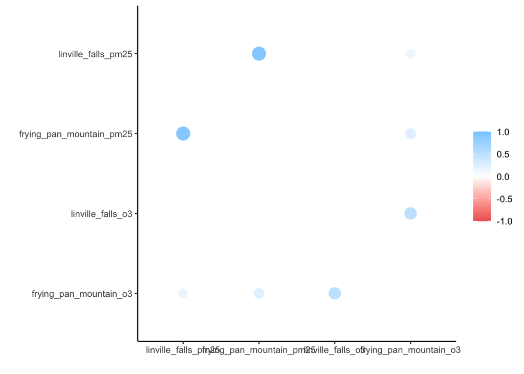

```r
cor_levels_o3_p25 <- levels_o3_p25 %>% select(-date) %>% corrr::correlate()
cor_plot <- cor_levels_o3_p25 %>% rplot()
cor_plot
```

### Fit the four regression models then combine them into a single table

```r
modelOne <- lm(linville_falls_pm25~frying_pan_mountain_pm25, data= levels_o3_p25)

modelTwo <- lm(linville_falls_pm25~frying_pan_mountain_pm25 + frying_pan_mountain_o3, data= levels_o3_p25)

modelThree <- lm(linville_falls_o3~frying_pan_mountain_o3, data= levels_o3_p25)

modelFour <- lm(linville_falls_o3~frying_pan_mountain_pm25 + frying_pan_mountain_o3, data= levels_o3_p25)

reg_models <- modelOne %>% glance()  %>% full_join(modelTwo %>% glance() ) %>%
  full_join(modelThree%>% glance() ) %>%
  full_join(modelFour%>% glance() )
reg_models
```

```
## # A tibble: 4 × 12
##   r.squared adj.r.squared   sigma statistic  p.value    df logLik   AIC   BIC
##       <dbl>         <dbl>   <dbl>     <dbl>    <dbl> <dbl>  <dbl> <dbl> <dbl>
## 1     0.827         0.825 1.08        411.  1.58e-34     1  -131.  268.  275.
## 2     0.830         0.826 1.08        203.  1.09e-32     2  -127.  262.  272.
## 3     0.453         0.446 0.00666      67.8 2.39e-12     1   303. -599. -592.
## 4     0.541         0.528 0.00620      42.4 6.73e-13     2   276. -545. -535.
## # … with 3 more variables: deviance <dbl>, df.residual <int>, nobs <int>
```

### Plot Observed Ozone at Linville Falls vs Frying Pan Mountain

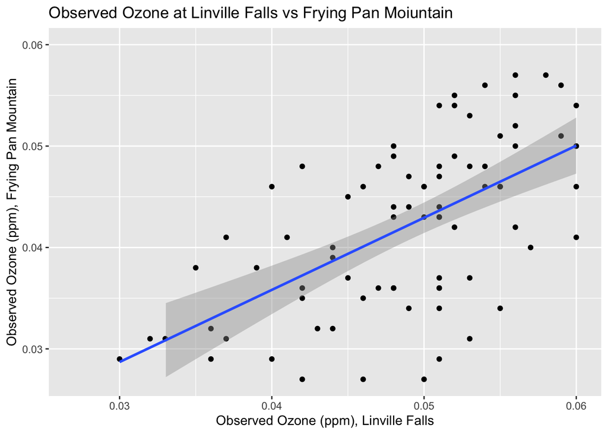

```r
scale <- c(.027,.06)
levels_o3_p25 %>%
  add_residuals(modelThree) %>%
  add_predictions(modelThree) %>%
  ggplot(aes(y=linville_falls_o3, x= frying_pan_mountain_o3)) +
  scale_x_continuous(name="Observed Ozone (ppm), Linville Falls",limits = scale) +
  scale_y_continuous(name="Observed Ozone (ppm), Frying Pan Mountain", limits = scale) +
  geom_point() +
  geom_smooth(method = 'lm') +
  labs(title="Observed Ozone at Linville Falls vs Frying Pan Moiuntain")
```

### Plot Predicted vs Observed Ozone at Linville Falls

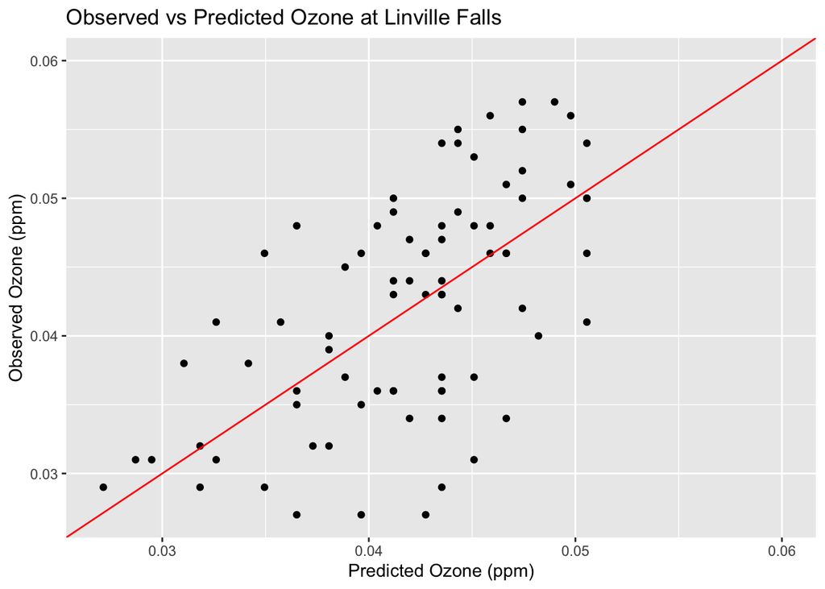

```r
levels_o3_p25 %>% add_predictions(modelThree) %>%
  ggplot(aes(x=pred, y=linville_falls_o3)) +
  scale_x_continuous(name="Predicted Ozone (ppm)",limits = scale) +
  scale_y_continuous(name="Observed Ozone (ppm)", limits = scale) +
  geom_point() +
  geom_abline(slope = 1,intercept = 0, color='red') +
  labs(title="Observed vs Predicted Ozone at Linville Falls")
```

# Conclusion

In my opinion the station should not be decommissioned. As seen in the plot of the comparison plot of observed vs predicted ozone, the prediction of ozone based on the Frying Pan Mountain Data significantly deviates from the observed data at Lineville falls. This deviation can also be seen in the comparison of observed ozone plot of Lineville Falls vs Frying Pan Mountain. The reader can see that very few values fall into the liner regression models prediction.